# Machine Learning Workflow: Lasso Regression

Biostat 212A

Author

Dr. Jin Zhou @ UCLA

Published

February 18, 2025

Display system information for reproducibility.

**R**

**Python**

```python
import IPython
print(IPython.sys_info())
```

```
{'commit_hash': '22d6a1c16',
 'commit_source': 'installation',
 'default_encoding': 'utf-8',
 'ipython_path': '/Users/jinjinzhou/.virtualenvs/r-reticulate/lib/python3.13/site-packages/IPython',
 'ipython_version': '8.31.0',
 'os_name': 'posix',
 'platform': 'macOS-15.3.1-arm64-arm-64bit-Mach-O',
 'sys_executable': '/Users/jinjinzhou/.virtualenvs/r-reticulate/bin/python',
 'sys_platform': 'darwin',
 'sys_version': '3.13.0 (main, Oct  7 2024, 05:02:14) [Clang 16.0.0 '
                '(clang-1600.0.26.4)]'}
```

## 1 What is tidymodels?

The tidymodels framework is a package ecosystem, in which all steps of the machine learning workflow are implemented through dedicated R packages. The consistency of these packages ensures their interoperability and ease of use. Most importantly, the framework should make your machine learning workflow easier to understand and faster to implement.

Below you can see the basic machine learning workflow and how it maps to existing packages from tidymodels:

[figure not shown]

1. Preprocess: Transform and prepare data for modeling -> `recipes`
2. Model: Select and specify a model for a specific problem -> `parsnip`
3. Measure: Evaluate the performance of the model -> `yardstick`
4. Sample: Split and sample input data to evaluate models -> `rsample`
5. Tune: Adjust and improve the model on input data -> `tune`

## 2 Overview

[figure not shown]

We illustrate the typical machine learning workflow for regression problems using the `Hitters` data set from R `ISLR2` package. The steps are

1. Initial splitting to test and non-test sets.
2. Pre-processing of data (pipeline in Python, recipe in R).
3. Choose a learner/method Lasso in this example.
4. Tune the hyper-parameter(s) ($\lambda$ in this example) using $K$-fold cross-validation (CV) on the non-test data.
5. Choose the best model by CV and refit it on the whole non-test data.
6. Final prediction on the test data.

These steps completes the process of training and evaluating **one** machine learning method (lasso in this case). We repeat the same process for other learners, e.g., random forest or neural network, using the same test/non-test and CV split. The final report compares the learners based on CV and test errors.

## 3 Hitters data

[figure not shown]

A documentation of the `Hitters` data is [here](https://www.rdocumentation.org/packages/ISLR2/versions/1.3-2/topics/Hitters). The goal is to predict the salary (at opening of 1987 season) of MLB players from their performance metrics in the 1986-7 season.

**R**

```r
library(GGally)
library(ISLR2)
library(tidymodels)
library(tidyverse)

Hitters <- as_tibble(Hitters) %>% print(width = Inf)
```

```
# A tibble: 322 × 20
   AtBat  Hits HmRun  Runs   RBI Walks Years CAtBat CHits CHmRun CRuns  CRBI
   <int> <int> <int> <int> <int> <int> <int>  <int> <int>  <int> <int> <int>
 1   293    66     1    30    29    14     1    293    66      1    30    29
 2   315    81     7    24    38    39    14   3449   835     69   321   414
 3   479   130    18    66    72    76     3   1624   457     63   224   266
 4   496   141    20    65    78    37    11   5628  1575    225   828   838
 5   321    87    10    39    42    30     2    396   101     12    48    46
 6   594   169     4    74    51    35    11   4408  1133     19   501   336
 7   185    37     1    23     8    21     2    214    42      1    30     9
 8   298    73     0    24    24     7     3    509   108      0    41    37
 9   323    81     6    26    32     8     2    341    86      6    32    34
10   401    92    17    49    66    65    13   5206  1332    253   784   890
   CWalks League Division PutOuts Assists Errors Salary NewLeague
    <int> <fct>  <fct>      <int>   <int>  <int>  <dbl> <fct>
 1     14 A      E            446      33     20   NA   A
 2    375 N      W            632      43     10  475   N
 3    263 A      W            880      82     14  480   A
 4    354 N      E            200      11      3  500   N
 5     33 N      E            805      40      4   91.5 N
 6    194 A      W            282     421     25  750   A
 7     24 N      E             76     127      7   70   A
 8     12 A      W            121     283      9  100   A
 9      8 N      W            143     290     19   75   N
10    866 A      E              0       0      0 1100   A
# ℹ 312 more rows
```

```r
# Numerical summaries
summary(Hitters)
```

```
     AtBat            Hits         HmRun            Runs
 Min.   : 16.0   Min.   :  1   Min.   : 0.00   Min.   :  0.00
 1st Qu.:255.2   1st Qu.: 64   1st Qu.: 4.00   1st Qu.: 30.25
 Median :379.5   Median : 96   Median : 8.00   Median : 48.00
 Mean   :380.9   Mean   :101   Mean   :10.77   Mean   : 50.91
 3rd Qu.:512.0   3rd Qu.:137   3rd Qu.:16.00   3rd Qu.: 69.00
 Max.   :687.0   Max.   :238   Max.   :40.00   Max.   :130.00

      RBI             Walks            Years            CAtBat
 Min.   :  0.00   Min.   :  0.00   Min.   : 1.000   Min.   :   19.0
 1st Qu.: 28.00   1st Qu.: 22.00   1st Qu.: 4.000   1st Qu.:  816.8
 Median : 44.00   Median : 35.00   Median : 6.000   Median : 1928.0
 Mean   : 48.03   Mean   : 38.74   Mean   : 7.444   Mean   : 2648.7
 3rd Qu.: 64.75   3rd Qu.: 53.00   3rd Qu.:11.000   3rd Qu.: 3924.2
 Max.   :121.00   Max.   :105.00   Max.   :24.000   Max.   :14053.0

     CHits            CHmRun           CRuns             CRBI
 Min.   :   4.0   Min.   :  0.00   Min.   :   1.0   Min.   :   0.00
 1st Qu.: 209.0   1st Qu.: 14.00   1st Qu.: 100.2   1st Qu.:  88.75
 Median : 508.0   Median : 37.50   Median : 247.0   Median : 220.50
 Mean   : 717.6   Mean   : 69.49   Mean   : 358.8   Mean   : 330.12
 3rd Qu.:1059.2   3rd Qu.: 90.00   3rd Qu.: 526.2   3rd Qu.: 426.25
 Max.   :4256.0   Max.   :548.00   Max.   :2165.0   Max.   :1659.00

     CWalks        League  Division    PutOuts          Assists
 Min.   :   0.00   A:175   E:157    Min.   :   0.0   Min.   :  0.0
 1st Qu.:  67.25   N:147   W:165    1st Qu.: 109.2   1st Qu.:  7.0
 Median : 170.50                    Median : 212.0   Median : 39.5
 Mean   : 260.24                    Mean   : 288.9   Mean   :106.9
 3rd Qu.: 339.25                    3rd Qu.: 325.0   3rd Qu.:166.0
 Max.   :1566.00                    Max.   :1378.0   Max.   :492.0

     Errors          Salary       NewLeague
 Min.   : 0.00   Min.   :  67.5   A:176
 1st Qu.: 3.00   1st Qu.: 190.0   N:146
 Median : 6.00   Median : 425.0
 Mean   : 8.04   Mean   : 535.9
 3rd Qu.:11.00   3rd Qu.: 750.0
 Max.   :32.00   Max.   :2460.0
                 NA's   :59
```

Graphical summary takes longer to run so suppressed here.

```r
# Graphical summaries
ggpairs(
  data = Hitters,
  mapping = aes(alpha = 0.25),
  lower = list(continuous = "smooth")
  ) +
  labs(title = "Hitters Data")
```

There are 59 `NA`s for the salary. Let’s drop those cases. We are left with 263 data points.

```r
Hitters <- Hitters %>%
  drop_na()
dim(Hitters)
```

```
[1] 263  20
```

**Python**

```python
# Load the pandas library
import pandas as pd
# Load numpy for array manipulation
import numpy as np
# Load seaborn plotting library
import seaborn as sns
import matplotlib.pyplot as plt

# Set font sizes in plots
sns.set(font_scale = 2)
# Display all columns
pd.set_option('display.max_columns', None)

Hitters = pd.read_csv("../data/Hitters.csv")
Hitters
```

```
     AtBat  Hits  HmRun  Runs  RBI  Walks  Years  CAtBat  CHits  CHmRun  \
0      293    66      1    30   29     14      1     293     66       1
1      315    81      7    24   38     39     14    3449    835      69
2      479   130     18    66   72     76      3    1624    457      63
3      496   141     20    65   78     37     11    5628   1575     225
4      321    87     10    39   42     30      2     396    101      12
..     ...   ...    ...   ...  ...    ...    ...     ...    ...     ...
317    497   127      7    65   48     37      5    2703    806      32
318    492   136      5    76   50     94     12    5511   1511      39
319    475   126      3    61   43     52      6    1700    433       7
320    573   144      9    85   60     78      8    3198    857      97
321    631   170      9    77   44     31     11    4908   1457      30

     CRuns  CRBI  CWalks League Division  PutOuts  Assists  Errors  Salary  \
0       30    29      14      A        E      446       33      20     NaN
```

[output cut: 25 more lines]

```python
# Numerical summaries
Hitters.info()
```

```
<class 'pandas.core.frame.DataFrame'>
RangeIndex: 322 entries, 0 to 321
Data columns (total 20 columns):
 #   Column     Non-Null Count  Dtype
---  ------     --------------  -----
 0   AtBat      322 non-null    int64
 1   Hits       322 non-null    int64
 2   HmRun      322 non-null    int64
 3   Runs       322 non-null    int64
 4   RBI        322 non-null    int64
 5   Walks      322 non-null    int64
 6   Years      322 non-null    int64
 7   CAtBat     322 non-null    int64
 8   CHits      322 non-null    int64
 9   CHmRun     322 non-null    int64
 10  CRuns      322 non-null    int64
 11  CRBI       322 non-null    int64
 12  CWalks     322 non-null    int64
 13  League     322 non-null    object
 14  Division   322 non-null    object
 15  PutOuts    322 non-null    int64
 16  Assists    322 non-null    int64
 17  Errors     322 non-null    int64
 18  Salary     263 non-null    float64
 19  NewLeague  322 non-null    object
dtypes: float64(1), int64(16), object(3)
memory usage: 50.4+ KB
```

```python
Hitters.describe()
```

```
            AtBat        Hits       HmRun        Runs         RBI       Walks  \
count  322.000000  322.000000  322.000000  322.000000  322.000000  322.000000
mean   380.928571  101.024845   10.770186   50.909938   48.027950   38.742236
std    153.404981   46.454741    8.709037   26.024095   26.166895   21.639327
min     16.000000    1.000000    0.000000    0.000000    0.000000    0.000000
25%    255.250000   64.000000    4.000000   30.250000   28.000000   22.000000
50%    379.500000   96.000000    8.000000   48.000000   44.000000   35.000000
75%    512.000000  137.000000   16.000000   69.000000   64.750000   53.000000
max    687.000000  238.000000   40.000000  130.000000  121.000000  105.000000

            Years       CAtBat        CHits      CHmRun        CRuns  \
count  322.000000    322.00000   322.000000  322.000000   322.000000
mean     7.444099   2648.68323   717.571429   69.490683   358.795031
std      4.926087   2324.20587   654.472627   86.266061   334.105886
min      1.000000     19.00000     4.000000    0.000000     1.000000
25%      4.000000    816.75000   209.000000   14.000000   100.250000
50%      6.000000   1928.00000   508.000000   37.500000   247.000000
75%     11.000000   3924.25000  1059.250000   90.000000   526.250000
max     24.000000  14053.00000  4256.000000  548.000000  2165.000000

              CRBI       CWalks      PutOuts     Assists      Errors  \
count   322.000000   322.000000   322.000000  322.000000  322.000000
mean    330.118012   260.239130   288.937888  106.913043    8.040373
std     333.219617   267.058085   280.704614  136.854876    6.368359
min       0.000000     0.000000     0.000000    0.000000    0.000000
25%      88.750000    67.250000   109.250000    7.000000    3.000000
50%     220.500000   170.500000   212.000000   39.500000    6.000000
75%     426.250000   339.250000   325.000000  166.000000   11.000000
max    1659.000000  1566.000000  1378.000000  492.000000   32.000000

            Salary
count   263.000000
mean    535.925882
std     451.118681
min      67.500000
25%     190.000000
50%     425.000000
75%     750.000000
max    2460.000000
```

Graphical summary takes longer to run so suppressed here.

```python
# Graphical summaries
sns.pairplot(data = Hitters)
```

There are 59 `NA`s for the salary. Let’s drop those cases. We are left with 263 data points.

```python
Hitters.dropna(inplace = True)
Hitters.shape
```

```
(263, 20)
```

## 4 Initial split into test and non-test sets

**R**

```r
# For reproducibility
set.seed(425)
data_split <- initial_split(
  Hitters,
  # # stratify by percentilesk
  # strata = "Salary",
  prop = 0.75
  )

Hitters_other <- training(data_split)
dim(Hitters_other)
```

```
[1] 197  20
```

```r
Hitters_test <- testing(data_split)
dim(Hitters_test)
```

```
[1] 66 20
```

**Python**

```python
from sklearn.model_selection import train_test_split

Hitters_other, Hitters_test = train_test_split(
  Hitters,
  train_size = 0.75,
  random_state = 425, # seed
  )
Hitters_test.shape
```

```
(66, 20)
```

```python
Hitters_other.shape
```

```
(197, 20)
```

Separate $X$ and $y$.

```python
# Non-test X and y
X_other = Hitters_other.drop('Salary', axis = 1)
y_other = Hitters_other.Salary
# Test X and y
X_test = Hitters_test.drop('Salary', axis = 1)
y_test = Hitters_test.Salary
```

## 5 Preprocessing (Python) or recipe (R)

For regularization methods such as ridge and lasso, it is essential to center and scale predictors.

**R**

```r
norm_recipe <-
  recipe(
    Salary ~ .,
    data = Hitters_other
  ) %>%
  # create traditional dummy variables
  step_dummy(all_nominal()) %>%
  # zero-variance filter
  step_zv(all_predictors()) %>%
  # center and scale numeric data
  step_normalize(all_predictors()) # %>%
  # step_log(Salary, base = 10) %>%
  # estimate the means and standard deviations
  # prep(training = Hitters_other, retain = TRUE)
norm_recipe
```

**Python**

Pre-processor for one-hot coding of categorical variables and then standardizing all numeric predictors.

```python
from sklearn.preprocessing import OneHotEncoder, StandardScaler
from sklearn.compose import make_column_transformer
from sklearn.pipeline import Pipeline

# OHE transformer for categorical variables
cattf = make_column_transformer(
  (OneHotEncoder(drop = 'first'), ['League', 'Division', 'NewLeague']),
  remainder = 'passthrough'
)
# Standardization transformer
scalar = StandardScaler()
```

## 6 Model

- We use the `glmnet` package in R for ridge and lasso regression.
- `parsnip`: https://parsnip.tidymodels.org/reference/linear_reg.html for R.

**R**

```r
lasso_mod <-
  # mixture = 0 (ridge), mixture = 1 (lasso)
  linear_reg(penalty = tune(), mixture = 1.0) %>%
  set_engine("glmnet")
lasso_mod
```

```
Linear Regression Model Specification (regression)

Main Arguments:
  penalty = tune()
  mixture = 1

Computational engine: glmnet
```

**Python**

```python
from sklearn.linear_model import Lasso

lasso = Lasso(max_iter = 10000)
lasso
```

```
Lasso(max_iter=10000)
```

## 7 Pipeline (Python) or workflow (R)

Here we bundle the preprocessing step (Python) or recipe (R) and model.

**R**

```r
lr_wf <-
  workflow() %>%
  add_model(lasso_mod) %>%
  add_recipe(norm_recipe)
lr_wf
```

```
══ Workflow ════════════════════════════════════════════════════════════════════
Preprocessor: Recipe
Model: linear_reg()

── Preprocessor ────────────────────────────────────────────────────────────────
3 Recipe Steps

• step_dummy()
• step_zv()
• step_normalize()

── Model ───────────────────────────────────────────────────────────────────────
Linear Regression Model Specification (regression)

Main Arguments:
  penalty = tune()
  mixture = 1

Computational engine: glmnet
```

**Python**

```python
pipe = Pipeline(steps = [
  ("cat_tf", cattf),
  ("std_tf", scalar),
  ("model", lasso)
  ])
pipe
```

```
Pipeline(steps=[('cat_tf',
                 ColumnTransformer(remainder='passthrough',
                                   transformers=[('onehotencoder',
                                                  OneHotEncoder(drop='first'),
                                                  ['League', 'Division',
                                                   'NewLeague'])])),
                ('std_tf', StandardScaler()),
                ('model', Lasso(max_iter=10000))])
```

## 8 Tuning grid

**R**

https://dials.tidymodels.org/reference/dials-package.html

```r
lambda_grid <-
  grid_regular(penalty(range = c(-2, 1.5), trans = log10_trans()), levels = 100)
lambda_grid
```

```
# A tibble: 100 × 1
   penalty
     <dbl>
 1  0.01
 2  0.0108
 3  0.0118
 4  0.0128
 5  0.0138
 6  0.0150
 7  0.0163
 8  0.0177
 9  0.0192
10  0.0208
# ℹ 90 more rows
```

**Python**

```python
# Tune hyper-parameter(s)
alphas = np.logspace(start = -3, stop = 2, base = 10, num = 100)
tuned_parameters = {"model__alpha": alphas}
```

## 9 Cross-validation (CV)

**R**

Set cross-validation partitions.

```r
set.seed(250)
folds <- vfold_cv(Hitters_other, v = 10)
folds
```

```
#  10-fold cross-validation
# A tibble: 10 × 2
   splits           id
   <list>           <chr>
 1 <split [177/20]> Fold01
 2 <split [177/20]> Fold02
 3 <split [177/20]> Fold03
 4 <split [177/20]> Fold04
 5 <split [177/20]> Fold05
 6 <split [177/20]> Fold06
 7 <split [177/20]> Fold07
 8 <split [178/19]> Fold08
 9 <split [178/19]> Fold09
10 <split [178/19]> Fold10
```

Fit cross-validation.

```r
lasso_fit <-
  lr_wf %>%
  tune_grid(
    resamples = folds,
    grid = lambda_grid)
lasso_fit
```

```
# Tuning results
# 10-fold cross-validation
# A tibble: 10 × 4
   splits           id     .metrics           .notes
   <list>           <chr>  <list>             <list>
 1 <split [177/20]> Fold01 <tibble [200 × 5]> <tibble [0 × 3]>
 2 <split [177/20]> Fold02 <tibble [200 × 5]> <tibble [0 × 3]>
 3 <split [177/20]> Fold03 <tibble [200 × 5]> <tibble [0 × 3]>
 4 <split [177/20]> Fold04 <tibble [200 × 5]> <tibble [0 × 3]>
 5 <split [177/20]> Fold05 <tibble [200 × 5]> <tibble [0 × 3]>
 6 <split [177/20]> Fold06 <tibble [200 × 5]> <tibble [0 × 3]>
 7 <split [177/20]> Fold07 <tibble [200 × 5]> <tibble [0 × 3]>
 8 <split [178/19]> Fold08 <tibble [200 × 5]> <tibble [0 × 3]>
 9 <split [178/19]> Fold09 <tibble [200 × 5]> <tibble [0 × 3]>
10 <split [178/19]> Fold10 <tibble [200 × 5]> <tibble [0 × 3]>
```

Visualize CV criterion.

```
# A tibble: 200 × 7
   penalty .metric .estimator    mean     n std_err .config
     <dbl> <chr>   <chr>        <dbl> <int>   <dbl> <chr>
 1  0.01   rmse    standard   341.       10 33.2    Preprocessor1_Model001
 2  0.01   rsq     standard     0.472    10  0.0845 Preprocessor1_Model001
 3  0.0108 rmse    standard   341.       10 33.2    Preprocessor1_Model002
 4  0.0108 rsq     standard     0.472    10  0.0845 Preprocessor1_Model002
 5  0.0118 rmse    standard   341.       10 33.2    Preprocessor1_Model003
 6  0.0118 rsq     standard     0.472    10  0.0845 Preprocessor1_Model003
 7  0.0128 rmse    standard   341.       10 33.2    Preprocessor1_Model004
 8  0.0128 rsq     standard     0.472    10  0.0845 Preprocessor1_Model004
 9  0.0138 rmse    standard   341.       10 33.2    Preprocessor1_Model005
10  0.0138 rsq     standard     0.472    10  0.0845 Preprocessor1_Model005
# ℹ 190 more rows
```

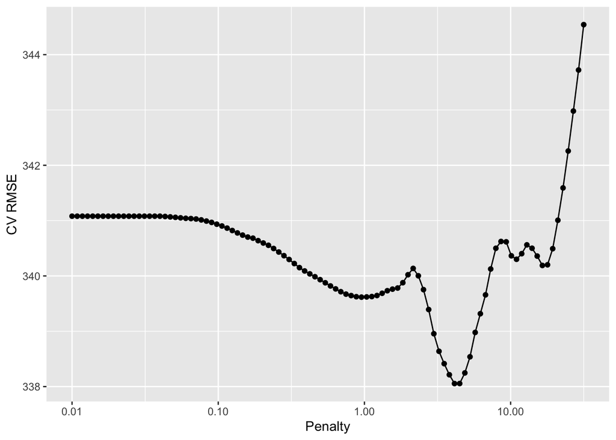

```r
lasso_fit %>%
  collect_metrics() %>%
  print(width = Inf) %>%
  filter(.metric == "rmse") %>%
  ggplot(mapping = aes(x = penalty, y = mean)) +
  geom_point() +
  geom_line() +
  labs(x = "Penalty", y = "CV RMSE") +
  scale_x_log10(labels = scales::label_number())
```

Show the top 5 models ($\lambda$ values)

```r
lasso_fit %>%
  show_best(metric = "rmse")
```

```
# A tibble: 5 × 7
  penalty .metric .estimator  mean     n std_err .config
    <dbl> <chr>   <chr>      <dbl> <int>   <dbl> <chr>
1    4.13 rmse    standard    338.    10    38.0 Preprocessor1_Model075
2    4.48 rmse    standard    338.    10    38.2 Preprocessor1_Model076
3    3.81 rmse    standard    338.    10    37.9 Preprocessor1_Model074
4    4.86 rmse    standard    338.    10    38.4 Preprocessor1_Model077
5    3.51 rmse    standard    338.    10    37.7 Preprocessor1_Model073
```

Let’s select the best model

```r
best_lasso <- lasso_fit %>%
  select_best(metric = "rmse")
best_lasso
```

```
# A tibble: 1 × 2
  penalty .config
    <dbl> <chr>
1    4.13 Preprocessor1_Model075
```

**Python**

Set up CV partitions and CV criterion.

```python
from sklearn.model_selection import GridSearchCV

# Set up CV
n_folds = 10
search = GridSearchCV(
  pipe,
  tuned_parameters,
  cv = n_folds,
  scoring = "neg_root_mean_squared_error",
  # Refit the best model on the whole data set
  refit = True
  )
```

Fit CV. This is typically the most time-consuming step.

```python
# Fit CV
search.fit(X_other, y_other)
```

```
GridSearchCV(cv=10,
             estimator=Pipeline(steps=[('cat_tf',
                                        ColumnTransformer(remainder='passthrough',
                                                          transformers=[('onehotencoder',
                                                                         OneHotEncoder(drop='first'),
                                                                         ['League',
                                                                          'Division',
                                                                          'NewLeague'])])),
                                       ('std_tf', StandardScaler()),
                                       ('model', Lasso(max_iter=10000))]),
             param_grid={'model__alpha': array([1.00000000e-03, 1.12332403e-03, 1.26185688e-03, 1.41747416e-03,...
       6.89261210e+00, 7.74263683e+00, 8.69749003e+00, 9.77009957e+00,
       1.09749877e+01, 1.23284674e+01, 1.38488637e+01, 1.55567614e+01,
       1.74752840e+01, 1.96304065e+01, 2.20513074e+01, 2.47707636e+01,
       2.78255940e+01, 3.12571585e+01, 3.51119173e+01, 3.94420606e+01,
       4.43062146e+01, 4.97702356e+01, 5.59081018e+01, 6.28029144e+01,
       7.05480231e+01, 7.92482898e+01, 8.90215085e+01, 1.00000000e+02])},
             scoring='neg_root_mean_squared_error')
```

CV results.

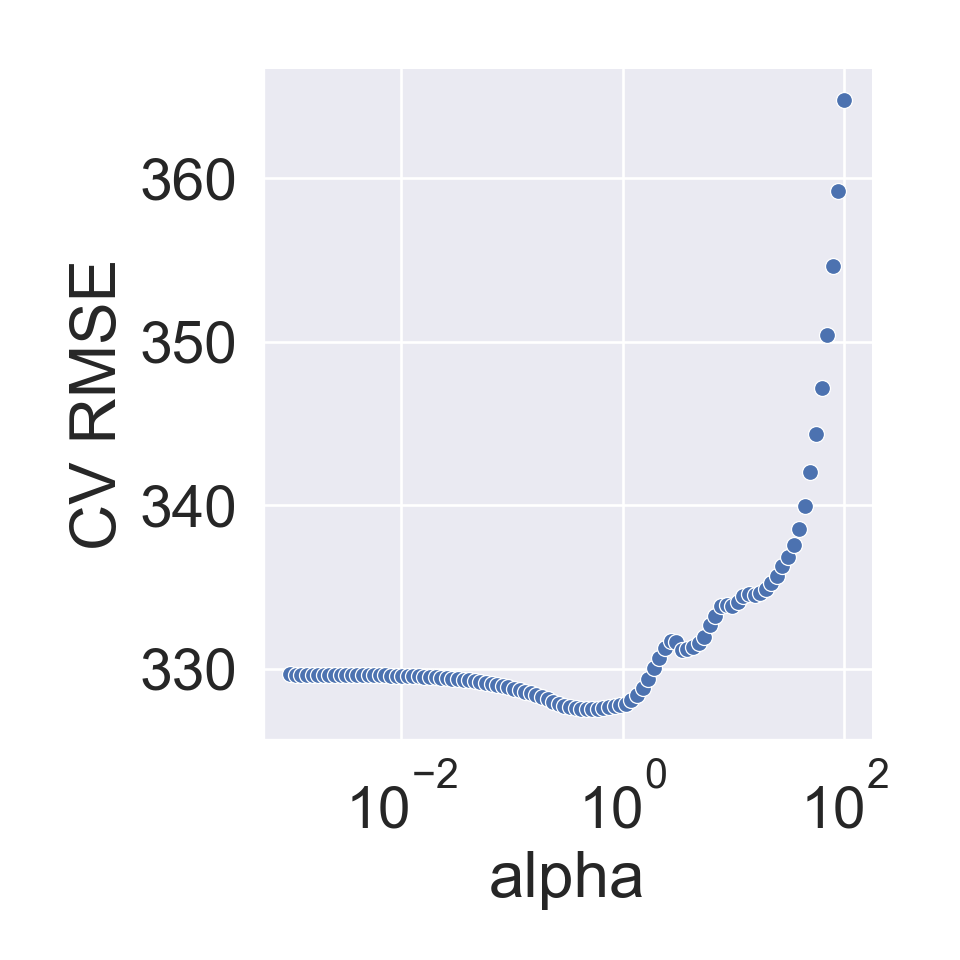

```python
cv_res = pd.DataFrame({
  "alpha": alphas,
  "rmse": -search.cv_results_["mean_test_score"]
  })

plt.figure()
sns.relplot(
  data = cv_res,
  x = "alpha",
  y = "rmse"
  ).set(
    xlabel = "alpha",
    ylabel = "CV RMSE",
    xscale = "log"
);
plt.show()
```

Best CV RMSE:

```python
-search.best_score_
```

```
np.float64(327.5225980405363)
```

## 10 Finalize our model

Now we are done tuning. Finally, let’s fit this final model to the whole training data and use our test data to estimate the model performance we expect to see with new data.

**R**

```r
# Final workflow
final_wf <- lr_wf %>%
  finalize_workflow(best_lasso)
final_wf
```

```
══ Workflow ════════════════════════════════════════════════════════════════════
Preprocessor: Recipe
Model: linear_reg()

── Preprocessor ────────────────────────────────────────────────────────────────
3 Recipe Steps

• step_dummy()
• step_zv()
• step_normalize()

── Model ───────────────────────────────────────────────────────────────────────
Linear Regression Model Specification (regression)

Main Arguments:
  penalty = 4.13201240011533
  mixture = 1

Computational engine: glmnet
```

```r
# Fit the whole training set, then predict the test cases
final_fit <-
  final_wf %>%
  last_fit(data_split)
final_fit
```

```
# Resampling results
# Manual resampling
# A tibble: 1 × 6
  splits           id               .metrics .notes   .predictions .workflow
  <list>           <chr>            <list>   <list>   <list>       <list>
1 <split [197/66]> train/test split <tibble> <tibble> <tibble>     <workflow>
```

```r
# Test metrics
final_fit %>% collect_metrics()
```

```
# A tibble: 2 × 4
  .metric .estimator .estimate .config
  <chr>   <chr>          <dbl> <chr>
1 rmse    standard     319.    Preprocessor1_Model1
2 rsq     standard       0.412 Preprocessor1_Model1
```

**Python**

Since we called `GridSearchCV` with `refit = True`, the best model fit on the whole non-test data is readily available.

```python
search.best_estimator_
```

```
Pipeline(steps=[('cat_tf',
                 ColumnTransformer(remainder='passthrough',
                                   transformers=[('onehotencoder',
                                                  OneHotEncoder(drop='first'),
                                                  ['League', 'Division',
                                                   'NewLeague'])])),
                ('std_tf', StandardScaler()),
                ('model',
                 Lasso(alpha=np.float64(0.4750810162102798), max_iter=10000))])
```

```python
from sklearn.metrics import mean_squared_error

mean_squared_error(y_test, search.best_estimator_.predict(X_test))
```

```
129252.73200779222
```

Test RMSE seems to be a bit off.